# Dutch Precipitation Catastrophe Model

- Show All Code
- Hide All Code
- View Source

Probabilistic nat cat model — GEV hazard, copula dependence, sigmoid vulnerability

Author

Richard Marek

Published

April 24, 2026

> **Note:** Exposure values and vulnerability parameters in this model are entirely synthetic. The hazard component (GEV distributions and copula) is fitted to real observational data from five Dutch meteorological stations; everything downstream is for educational and demonstration purposes only.

## Model Architecture

This catastrophe model follows the standard four-component structure used in commercial nat cat models (RMS, Verisk AIR, PERILS):

[output not shown]

The hazard component is carried over directly from the companion precipitation analysis. The GEV parameters and copula were estimated from [NOAA National Centers for Environmental Information (NCEI)](https://www.ncei.noaa.gov/products/land-based-station/global-historical-climatology-network-daily) daily records at five Dutch stations (Groningen, Roermond, Den Helder, Hoofddorp, Putten), covering approximately 1860–2020.

The annual loss simulation proceeds as follows for each simulated year, where $i = 1, \ldots, 5$ indexes the five model locations (Groningen, Roermond, Den Helder, Hoofddorp, Putten), each represented by a corresponding meteorological station and $c \in \{\text{resilient}, \text{vulnerable}\}$ denotes the building class:

1. Draw the number of events $N \sim \text{Poisson}(\lambda)$
2. For each event, draw a joint sample $\mathbf{U} = (U_1, \ldots, U_5) \sim C_{5D}$ from the 5-dimensional Gumbel copula, where $U_i \sim U(0,1)$ marginally
3. Transform to precipitation intensities via the inverse GEV distribution function: $H_i = F_i^{-1}(U_i;\, \hat{\mu}_i, \hat{\sigma}_i, \hat{\xi}_i)$, where $F_i^{-1}$ is the quantile function of the GEV distribution with location $\hat{\mu}_i$, scale $\hat{\sigma}_i$, and shape $\hat{\xi}_i$ estimated from observed annual maxima at station $i$
4. Apply station- and class-specific vulnerability functions $D_{ic}: [0, \infty) \to [0, 1]$ to obtain damage ratios: $D_{ic} = D(H_i;\, h_{0,ic},\, k_{ic}) \in [0, 1]$
5. Compute event loss $L = \sum_{i=1}^{5} \sum_{c} E_{ic} \cdot D_{ic}$, where $E_{ic} > 0$ is the total insured value (EUR) at location $i$ for building class $c$, and $D_{ic} \in [0,1]$ is the corresponding damage ratio from step 4
6. Sum event losses within the year to obtain annual loss: $L_{\text{year}} = \sum_{j=1}^{N} L^{(j)}$

Each model location represents an aggregated exposure cluster and is associated with a single meteorological station, whose fitted GEV distribution defines the local hazard intensity.

## Setup

```r
cop5d         <- readRDS("cop5d.rds")
params_table  <- readRDS("params_table.rds")
station_names <- readRDS("station_names.rds")

mu    <- params_table$mu
sigma <- params_table$sigma
xi    <- params_table$xi
```

## Portfolio

The synthetic portfolio assigns insured values (EUR) to two building classes at each of the five model locations. **Resilient** buildings represent modern, well-maintained structures with higher damage thresholds and shallower vulnerability curves. **Vulnerable** buildings represent older stock with lower thresholds and steeper curves — consistent with the distinction commonly made in commercial models between construction classes A and D.

```r
E <- matrix(c(
  3.0e9, 2.0e9,
  2.5e9, 1.5e9,
  4.0e9, 2.0e9,
  3.5e9, 1.5e9,
  2.0e9, 1.0e9
), nrow = 5, byrow = TRUE,
dimnames = list(station_names, c("resilient", "vulnerable")))

# Display
as.data.frame(E) %>%
  mutate("Model location" = station_names,
         Total   = resilient + vulnerable,
         across(c(resilient, vulnerable, Total),
                ~ paste0(round(.x / 1e9, 1), " bn EUR"))) %>%
  select("Model location", Resilient = resilient, Vulnerable = vulnerable, Total) %>%
  knitr::kable(caption = "Synthetic insured portfolio by model location and building class.",
                row.names = FALSE)
```

Synthetic insured portfolio by model location and building class.

| Model location | Resilient | Vulnerable | Total |
| --- | --- | --- | --- |
| Groningen | 3 bn EUR | 2 bn EUR | 5 bn EUR |
| Roermond | 2.5 bn EUR | 1.5 bn EUR | 4 bn EUR |
| Den Helder | 4 bn EUR | 2 bn EUR | 6 bn EUR |
| Hoofddorp | 3.5 bn EUR | 1.5 bn EUR | 5 bn EUR |
| Putten | 2 bn EUR | 1 bn EUR | 3 bn EUR |

Total insured value: **EUR 23 bn**.

## Vulnerability Functions

### Parameterisation

Each model location $i = 1, \ldots, 5$ and building class $c \in \{\text{resilient}, \text{vulnerable}\}$ has its own sigmoid vulnerability curve $D_{ic}: [0, \infty) \to [0, 1]$:

$$D_{ic}(h) = \frac{\tilde{\sigma}(h;\, h_{0,ic},\, k_{ic}) -
\tilde{\sigma}(0;\, h_{0,ic},\, k_{ic})}{1 - \tilde{\sigma}(0;\, h_{0,ic},\, k_{ic})},
\qquad
\tilde{\sigma}(h;\, h_0, k) = \frac{1}{1 + e^{-k(h - h_0)}}$$

where $h$ is precipitation intensity [mm], $h_{0,ic} > 0$ is the intensity at which model location $i$, class $c$ reaches a 50% damage ratio, and $k_{ic} > 0$ controls the steepness of the transition. The baseline correction $\tilde{\sigma}(0;\, h_{0,ic},\, k_{ic})$ ensures $D_{ic}(0) = 0$, so no damage is modelled at zero intensity. The parameters $h_{0,ic}$ and $k_{ic}$ are listed in the table below.

In commercial models (JBA, RMS, AIR), vulnerability curves are proprietary and calibrated against observed claims data, stratified by construction type, age, occupancy, and sometimes floor area. The parameters below are synthetic but reflect the general principle that resilient stock requires higher intensity before suffering significant damage, and transitions more gradually.

```r
vuln_params <- list(
  resilient = data.frame(
    station = station_names,
    h0 = c(90, 85, 95, 100, 88),
    k  = c(0.10, 0.09, 0.10, 0.11, 0.09)
  ),
  vulnerable = data.frame(
    station = station_names,
    h0 = c(60, 55, 65, 70, 58),
    k  = c(0.15, 0.13, 0.15, 0.17, 0.14)
  )
)

bind_rows(
  vuln_params$resilient %>% mutate(Class = "Resilient"),
  vuln_params$vulnerable %>% mutate(Class = "Vulnerable")
) %>%
  select(Class, "Model location" = station, "h₀" = h0, k) %>%
  knitr::kable(
    caption = "Vulnerability function parameters per model location and building class.
               h₀ = 50% damage threshold [mm], k = steepness.",
    digits = 2)
```

Vulnerability function parameters per model location and building class. h₀ = 50% damage threshold [mm], k = steepness.

| Class | Model location | h₀ | k |
| --- | --- | --- | --- |
| Resilient | Groningen | 90 | 0.10 |
| Resilient | Roermond | 85 | 0.09 |
| Resilient | Den Helder | 95 | 0.10 |
| Resilient | Hoofddorp | 100 | 0.11 |
| Resilient | Putten | 88 | 0.09 |
| Vulnerable | Groningen | 60 | 0.15 |
| Vulnerable | Roermond | 55 | 0.13 |
| Vulnerable | Den Helder | 65 | 0.15 |
| Vulnerable | Hoofddorp | 70 | 0.17 |
| Vulnerable | Putten | 58 | 0.14 |

### Vulnerability Curves

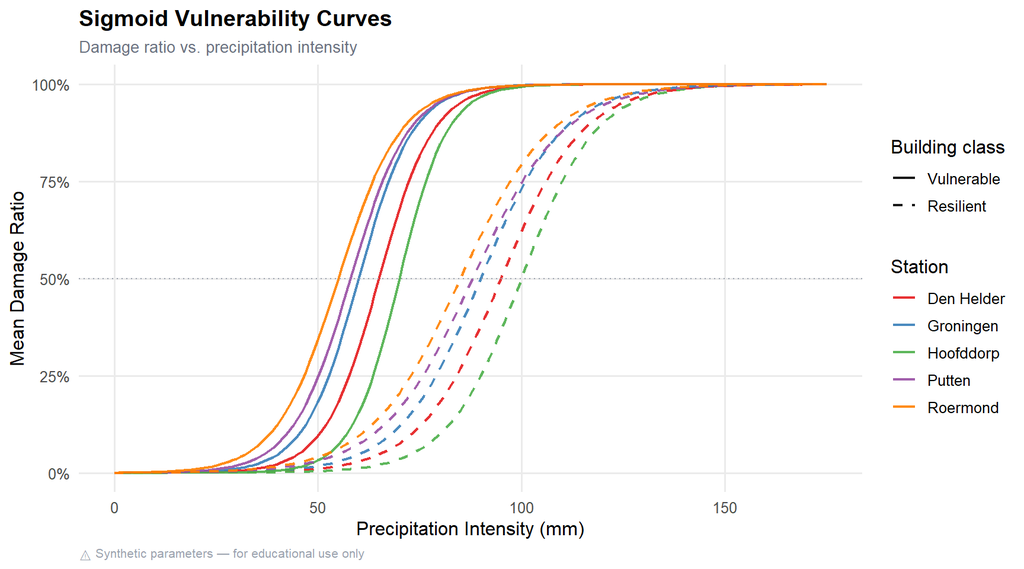

Sigmoid vulnerability curves. Resilient stock (dashed) requires substantially higher intensity before reaching significant damage ratios.

```r
vulnerability <- function(h, h0, k) {
  raw      <- 1 / (1 + exp(-k * (h - h0)))
  baseline <- 1 / (1 + exp(k * h0))
  pmax((raw - baseline) / (1 - baseline), 0)
}

h_seq <- seq(0, 175, by = 1)

vuln_curves <- bind_rows(lapply(c("resilient", "vulnerable"), function(cls) {
  vp <- vuln_params[[cls]]
  bind_rows(lapply(seq_len(nrow(vp)), function(i) {
    data.frame(
      station   = vp$station[i],
      class     = cls,
      intensity = h_seq,
      damage    = vulnerability(h_seq, vp$h0[i], vp$k[i])
    )
  }))
})) %>%
  mutate(class = factor(class,
                        levels = c("vulnerable", "resilient"),
                        labels = c("Vulnerable", "Resilient")))

midpoints <- vuln_curves %>%
  group_by(station, class) %>%
  summarise(h50 = intensity[which.min(abs(damage - 0.5))], .groups = "drop")

ggplot(vuln_curves, aes(x = intensity, y = damage,
                        colour = station, linetype = class)) +
  geom_line(linewidth = 0.85, alpha = 0.9) +
  #geom_point(data = midpoints,
  #           aes(x = h50, y = 0.5, colour = station),
  #           size = 2.5, shape = 21, fill = "white", stroke = 1.2,
  #           inherit.aes = FALSE) +
  geom_hline(yintercept = 0.5, colour = "#9CA3AF",
             linewidth = 0.4, linetype = "dotted") +
  scale_y_continuous(labels = percent_format(accuracy = 1),
                     limits = c(0, 1), breaks = seq(0, 1, 0.25)) +
  scale_colour_brewer(palette = "Set1", name = "Station") +
  scale_linetype_manual(name   = "Building class",
                        values = c("Vulnerable" = "solid", "Resilient" = "dashed")) +
  labs(title    = "Sigmoid Vulnerability Curves",
       subtitle = "Damage ratio vs. precipitation intensity",
       x        = "Precipitation Intensity (mm)",
       y        = "Mean Damage Ratio",
       caption  = "⚠ Synthetic parameters — for educational use only") +
  theme_minimal(base_size = 12) +
  theme(plot.title      = element_text(face = "bold"),
        plot.subtitle   = element_text(colour = "#6B7280", size = 10),
        plot.caption    = element_text(colour = "#9CA3AF", size = 8, hjust = 0),
        panel.grid.minor = element_blank())
```

## Simulation

### Event and Annual Loss Functions

```r
simulate_event_loss <- function(cop, mu, sigma, xi, E, vuln_params) {
  # 1. Draw joint sample from copula
  U <- as.numeric(rCopula(1, cop))

  # 2. Transform to precipitation intensities via inverse GEV
  H <- mapply(function(u, m, s, x) qgev(u, loc = m, scale = s, shape = x),
              U, mu, sigma, xi)
  H <- pmax(H, 0)   # intensity cannot be negative

  # 3. Apply vulnerability and compute loss
  loss <- 0
  for (cls in c("resilient", "vulnerable")) {
    vp   <- vuln_params[[cls]]
    D    <- mapply(vulnerability, H, vp$h0, vp$k)
    loss <- loss + sum(E[, cls] * D)
  }
  return(loss)
}

simulate_annual_loss <- function(cop, mu, sigma, xi, E, vuln_params, lambda = 0.5) {
  N          <- rpois(1, lambda)
  total_loss <- 0
  if (N > 0) {
    for (j in seq_len(N))
      total_loss <- total_loss +
        simulate_event_loss(cop, mu, sigma, xi, E, vuln_params)
  }
  return(total_loss)
}
```

### Monte Carlo Run (10,000 years)

```r
set.seed(123)
n_years       <- 10000
annual_losses <- numeric(n_years)

for (i in seq_len(n_years))
  annual_losses[i] <- simulate_annual_loss(cop5d, mu, sigma, xi, E, vuln_params)
```

## Results

### Risk Metrics

```r
AAL     <- mean(annual_losses)
VaR_99  <- quantile(annual_losses, 0.99)
VaR_995 <- quantile(annual_losses, 0.995)
TVaR_99 <- mean(annual_losses[annual_losses > VaR_99])

fmt <- function(x) paste0("EUR ", formatC(x / 1e9, format = "f", digits = 3), " bn")

data.frame(
  Metric = c("AAL", "VaR 99%", "VaR 99.5%", "TVaR 99%"),
  Value  = c(fmt(AAL), fmt(VaR_99), fmt(VaR_995), fmt(TVaR_99)),
  Interpretation = c(
    "Long-run expected annual loss; basis for risk-adjusted pricing",
    "1-in-100 year loss; common attachment point for excess of loss covers",
    "1-in-200 year loss; Solvency II SCR reference level",
    "Mean loss conditional on exceeding VaR 99%; coherent risk measure"
  )
) %>%
  knitr::kable(caption = "Portfolio-level risk metrics from 10,000-year Monte Carlo simulation.")
```

Portfolio-level risk metrics from 10,000-year Monte Carlo simulation.

| Metric | Value | Interpretation |
| --- | --- | --- |
| AAL | EUR 0.266 bn | Long-run expected annual loss; basis for risk-adjusted pricing |
| VaR 99% | EUR 3.295 bn | 1-in-100 year loss; common attachment point for excess of loss covers |
| VaR 99.5% | EUR 4.580 bn | 1-in-200 year loss; Solvency II SCR reference level |
| TVaR 99% | EUR 5.395 bn | Mean loss conditional on exceeding VaR 99%; coherent risk measure |

The AAL represents the pure risk premium — the minimum technically adequate rate for this portfolio ignoring expenses, profit loading, and cost of capital. The gap between VaR 99% and TVaR 99% reflects the heaviness of the tail: a large gap indicates that when losses exceed the 1-in-100 threshold, they tend to be substantially worse than that threshold — relevant for sizing catastrophe excess of loss programmes.

### Annual Loss Distribution

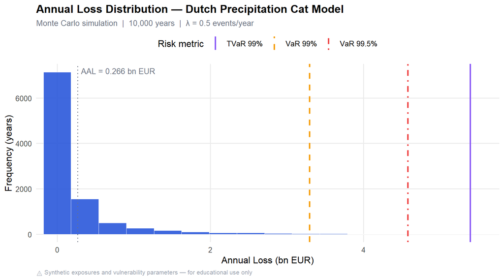

```r
loss_df <- data.frame(loss = annual_losses / 1e9)

metrics_df <- data.frame(
  label  = c("VaR 99%", "VaR 99.5%", "TVaR 99%"),
  value  = c(VaR_99, VaR_995, TVaR_99) / 1e9,
  colour = c("#F59E0B", "#EF4444", "#8B5CF6")
)

ggplot(loss_df, aes(x = loss)) +
  geom_histogram(bins = 60, fill = "#1D4ED8", colour = "white",
                 linewidth = 0.2, alpha = 0.85) +
  geom_vline(data = metrics_df,
             aes(xintercept = value, colour = label, linetype = label),
             linewidth = 0.9) +
  geom_vline(xintercept = AAL / 1e9,
             colour = "#6B7280", linewidth = 0.7, linetype = "dotted") +
  annotate("text", x = AAL / 1e9, y = Inf,
           label = sprintf("AAL = %.3f bn EUR", AAL / 1e9),
           vjust = 1.6, hjust = -0.05, size = 3.5, colour = "#6B7280") +
  scale_colour_manual(name   = "Risk metric",
                      values = setNames(metrics_df$colour, metrics_df$label)) +
  scale_linetype_manual(name   = "Risk metric",
                        values = c("VaR 99%"   = "dashed",
                                   "VaR 99.5%" = "dotdash",
                                   "TVaR 99%"  = "solid")) +
  coord_cartesian(xlim = c(0, 5.5)) +
  labs(title    = "Annual Loss Distribution — Dutch Precipitation Cat Model",
       subtitle = sprintf("Monte Carlo simulation  |  %s years  |  λ = 0.5 events/year",
                          formatC(n_years, format = "d", big.mark = ",")),
       x        = "Annual Loss (bn EUR)",
       y        = "Frequency (years)",
       caption  = "⚠ Synthetic exposures and vulnerability parameters — for educational use only") +
  theme_minimal(base_size = 12) +
  theme(plot.title       = element_text(face = "bold"),
        plot.subtitle    = element_text(colour = "#6B7280", size = 10),
        plot.caption     = element_text(colour = "#9CA3AF", size = 8, hjust = 0),
        legend.position  = "top",
        panel.grid.minor = element_blank())
```

### Exceedance Probability Curve (OEP vs AEP)

The Occurrence Exceedance Probability (OEP) curve shows the probability that the **largest single event loss** in a given year exceeds a given threshold. The Aggregate Exceedance Probability (AEP) curve shows the same for the **total annual loss** across all events. AEP lies above OEP because it includes the compounding effect of multiple events in a single year.

Both curves are standard outputs of cat model hazard modules and drive excess of loss reinsurance structuring. The shaded region indicates the 100–200 year return period range typically used for excess of loss attachment points and Solvency II capital calibration.

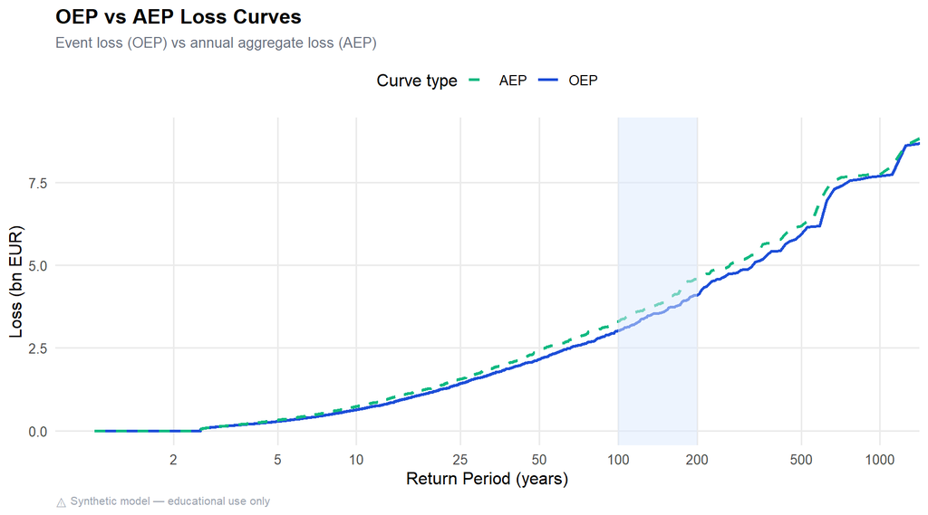

OEP and AEP curves. Shaded region = 100–200 year return period.

```r
# OEP: distribution of the maximum event loss per year
set.seed(123)
annual_losses    <- numeric(n_years)
max_event_losses <- numeric(n_years)

for (i in seq_len(n_years)) {
  N <- rpois(1, 0.5)
  if (N == 0) {
    annual_losses[i]    <- 0
    max_event_losses[i] <- 0
  } else {
    events <- replicate(N, simulate_event_loss(cop5d, mu, sigma, xi, E, vuln_params))
    annual_losses[i]    <- sum(events)
    max_event_losses[i] <- max(events)
  }
}


aep_df <- data.frame(loss = sort(annual_losses, decreasing = TRUE)) %>%
  mutate(rank          = seq_len(n()),
         exceedance_p  = rank / n_years,
         return_period = 1 / exceedance_p)

oep_df <- data.frame(loss = sort(max_event_losses, decreasing = TRUE)) %>%
  mutate(rank          = seq_len(n()),
         exceedance_p  = rank / n_years,
         return_period = 1 / exceedance_p)

ggplot() +
  # OEP (event loss)
  geom_line(data = oep_df,
            aes(x = return_period, y = loss / 1e9, colour = "OEP"),
            linewidth = 1) +
  # AEP (annual loss)
  geom_line(data = aep_df,
            aes(x = return_period, y = loss / 1e9, colour = "AEP"),
            linewidth = 1, linetype = "dashed") +
  annotate("rect", xmin = 100, xmax = 200, ymin = -Inf, ymax = Inf,
           fill = "#DBEAFE", alpha = 0.5) +
  scale_x_log10(breaks = c(2, 5, 10, 25, 50, 100, 200, 500, 1000),
                labels = c("2","5","10","25","50","100","200","500","1000")) +
  scale_colour_manual(name = "Curve type",
    values = c("OEP" = "#1D4ED8", "AEP" = "#10B981")) +
  coord_cartesian(xlim = c(1, 1000), ylim = c(0, 9)) +
  labs(title    = "OEP vs AEP Loss Curves",
    subtitle = "Event loss (OEP) vs annual aggregate loss (AEP)",
    x        = "Return Period (years)",
    y        = "Loss (bn EUR)",
    caption  = "⚠ Synthetic model — educational use only") +
  theme_minimal(base_size = 12) +
  theme(
    plot.title      = element_text(face = "bold"),
    plot.subtitle   = element_text(colour = "#6B7280", size = 10),
    plot.caption    = element_text(colour = "#9CA3AF", size = 8, hjust = 0),
    panel.grid.minor = element_blank(),
    legend.position  = "top"
  )
```

## Model Limitations

This model is a demonstration of the core cat modelling workflow. Several simplifications should be noted before drawing any conclusions from the numerical outputs:

**Hazard:** The GEV distributions and copula are fitted to annual maxima, which limits the effective sample to something between 150 and 200 observations per station. Non-stationarity in the mean is present at several stations (most markedly Roermond and Hoofddorp) and is not accounted for — return period estimates should be treated accordingly.

The 5D Gumbel copula is used here not because it is the best-fitting family, but because it is the only extreme value copula available for dimensions greater than 2 in R’s `copula` package. The thesis practical chapter, [Extreme Precipitation in the Netherlands: GEV Modelling & Extreme Value Copulas](https://risam0arek.github.io/precipitation-extremes-gev-copula/) shows that bivariate copula selection via AIC favours Hüsler–Reiss for 6 of 10 station pairs and t-EV for 3 pairs — neither of which generalises to five dimensions in standard R implementations. The Gumbel copula additionally constrains all pairwise dependences to a single parameter θ, whereas the bivariate analysis revealed heterogeneous dependence strengths across pairs. A vine copula would resolve both limitations but is left as a natural extension.

**Hazard metric:** Daily precipitation totals are used as the hazard intensity measure, which is a simplification. Flood damage is driven not only by peak daily rainfall but also by antecedent soil moisture, catchment characteristics, and multi-day accumulation — a 3-day or 5-day rolling maximum would better capture slow-onset riverine flooding, as opposed to flash floods where daily totals are more appropriate. River discharge data would be the most direct flood hazard metric, as it integrates all upstream processes, but sufficiently long records (100+ years) are not publicly available for most gauging stations at the resolution required for extreme value analysis.

**Frequency:** The Poisson rate $\lambda$ = 0.5 is a modelling assumption. In a production cat model, $\lambda$ would be calibrated against historical claims data or an event catalogue such as PERILS or Munich Re NatCatSERVICE. In the absence of such data, $\lambda$ is treated as a free parameter and is noted as a source of model uncertainty — small changes in $\lambda$ scale the AAL proportionally.

**Vulnerability:** Sigmoid curves are a standard functional form but real vulnerability functions are calibrated against observed insurance claims, stratified by construction type, age, number of storeys, and foundation type. The parameters here are illustrative.

**Exposure:** The portfolio is entirely synthetic. A real application would use geocoded policy data with sums insured per location.

## Connection to my Thesis Practical Chapter

This model operationalises the hazard analysis presented in the practical chapter of my thesis, [Extreme Precipitation in the Netherlands: GEV Modelling & Extreme Value Copulas](https://risam0arek.github.io/precipitation-extremes-gev-copula/), which covers GEV fitting, bivariate copula selection, and joint return period estimation in detail. The GEV parameters (`params_table.rds`) and the 5D copula (`cop5d.rds`) are loaded directly from that chapter without re-estimation.

The thesis practical chapter demonstrated that copula-implied joint exceedance probabilities are 14–98× higher than under independence for station pairs. That amplification carries through here: the dependence structure encoded in the copula is what determines the shape of the loss distribution tail — and therefore the VaR and TVaR estimates that drive reinsurance structuring and capital requirements.